# Лабораторная работа № 4

Реализация основных моделей в агентном подходе

Талебу Тенке Франк

2026-10-31

# Информация

## Докладчик

- **Талебу Тенке Франк**
- **Студенческий билет:** 1032224534
- Российский университет дружбы народов имени Патриса Лумумбы
- Дисциплина: Имитационное моделирование
- Лабораторная работа № 4

# Вводная часть

## Актуальность

- Распространение инфекции зависит от взаимодействий отдельных людей.
- Агентное моделирование учитывает индивидуальные характеристики и случайные события.
- В отличие от системы дифференциальных уравнений, модель Agents.jl описывает поведение агентов.

## Объект и предмет исследования

- **Объект:** распространение инфекционного заболевания в популяции.
- **Предмет:** динамика групп S, I, R и влияние заразности, миграции и параметров модели.

## Цели и задачи

**Цель:** реализовать агентную модель SIR с помощью Julia и Agents.jl.

- Запустить базовый эксперимент.
- Исследовать изменение коэффициента заразности.
- Оценить влияние миграции между городами.
- Рассмотреть оптимизацию параметров и итоговую визуализацию.

## Материалы и методы

- **Julia, Agents.jl:** программирование агентной модели.
- **SIR:** состояния восприимчивых, инфицированных и выздоровевших.
- **Параметрическое сканирование:** серия экспериментов при разных значениях заразности.
- **BlackBoxOptim:** многокритериальная оптимизация параметров.
- **Quarto и Jupyter:** оформление и воспроизводимость результатов.

## Ход выполнения работы

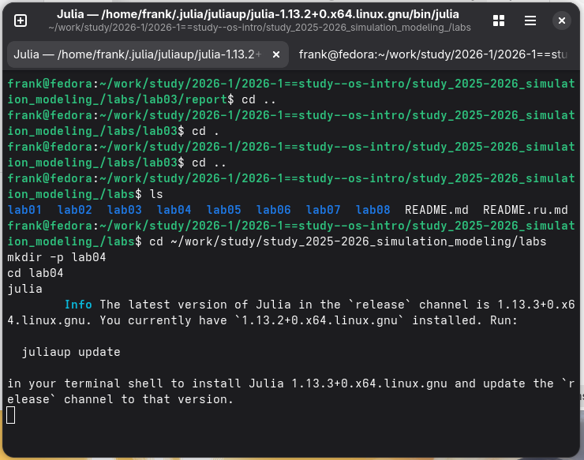

## выполнение

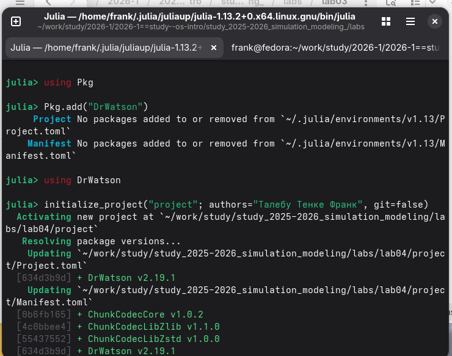

## выполнение

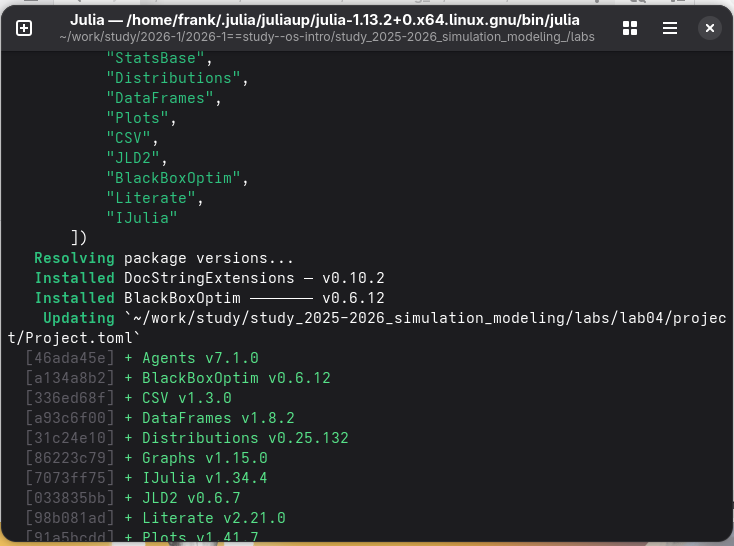

## выполнение

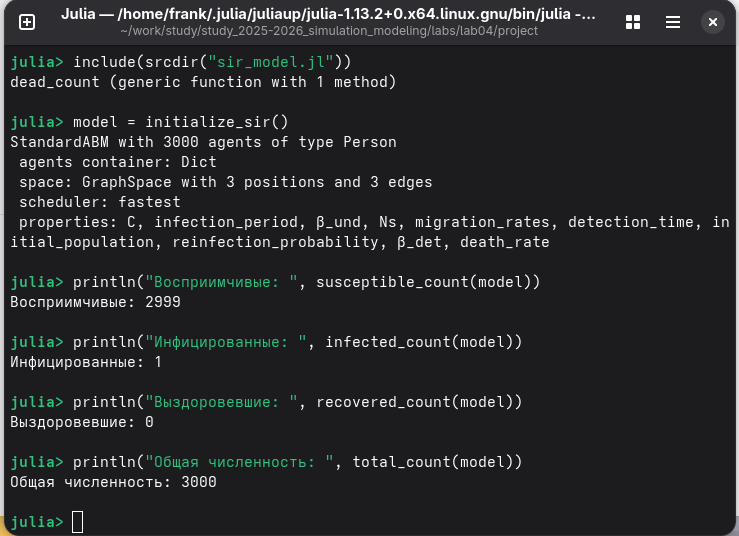

## выполнение

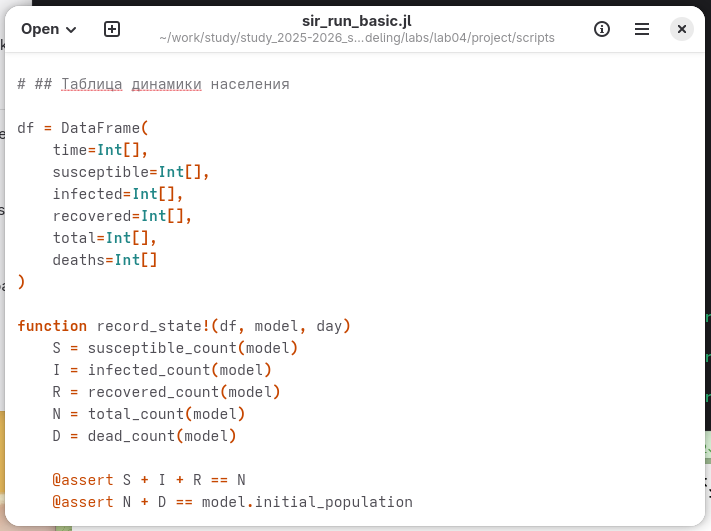

## выполнение

[figure not shown]

## выполнение

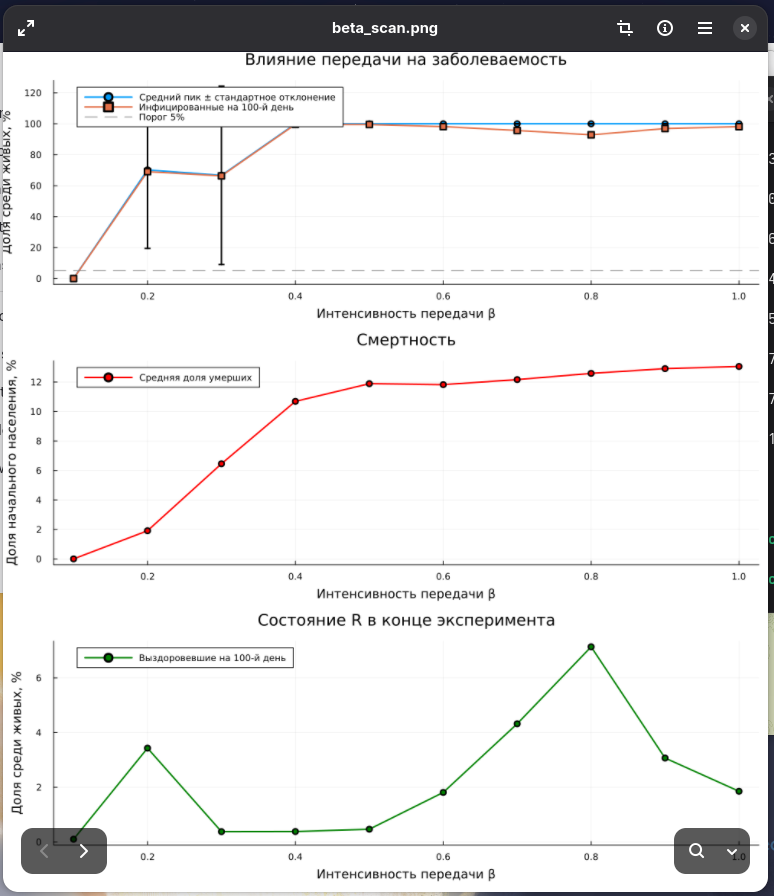

## выполнение

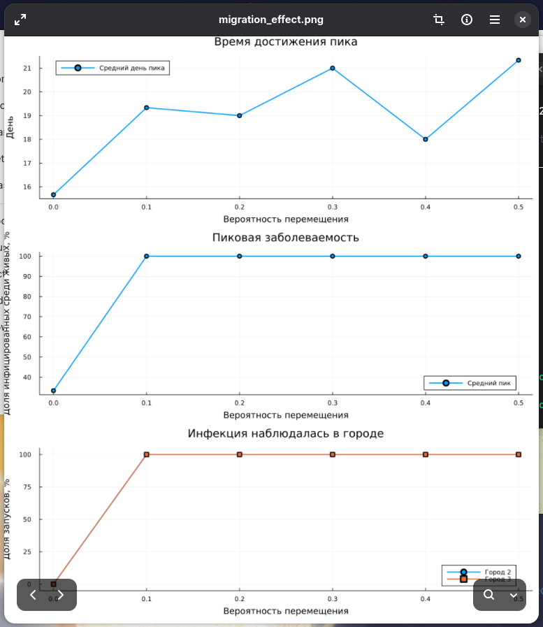

## выполнение

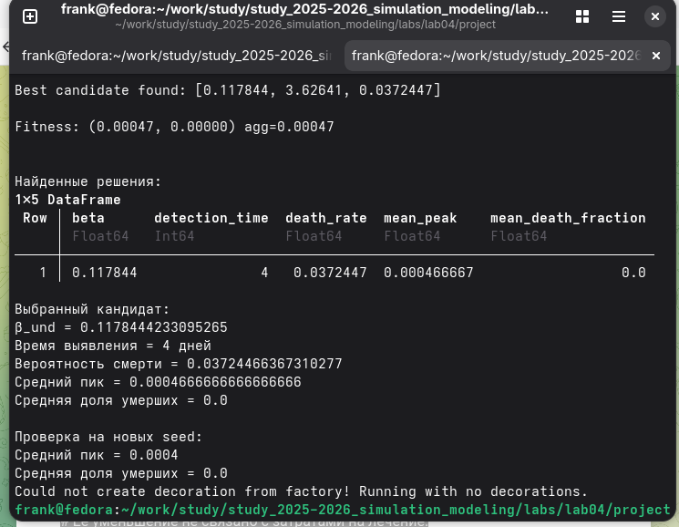

## выполнение

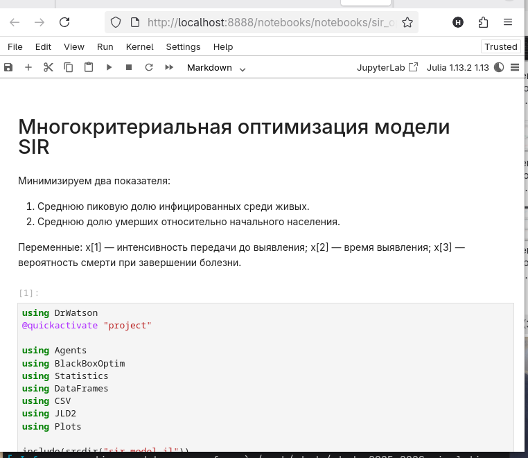

## выполнение

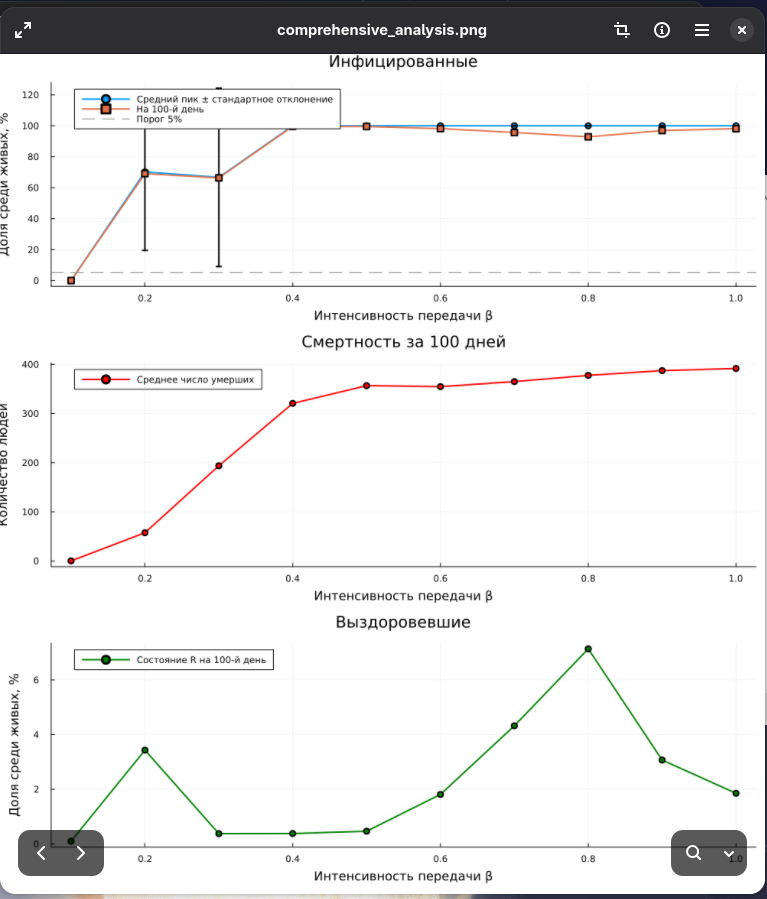

## выполнение

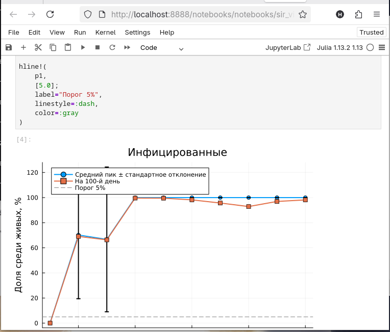

## Основные результаты

- Реализована и запущена агентная модель SIR.
- Получены графики базовой динамики эпидемии.
- Исследовано влияние заразности и миграции.
- Рассмотрены оптимизация параметров и сводный анализ результатов.

# Заключение

## Выводы

- Освоена реализация модели SIR в агентном подходе.
- Агентная модель позволяет учитывать индивидуальные взаимодействия и случайность.
- Серии экспериментов помогают оценить влияние параметров на динамику эпидемии.

## Спасибо за внимание!